# Prak Pertemuan 6

Muhammad Fadhil Hakim

2025-09-28

```r
library(ggplot2)
library(tsibble)
library(tseries)
library(MASS)
```

# Import Data

```r
library(readxl)
df <- read_excel("C:/prak/sem 5/MPDW/MPDW/Kurs Jual Rataan USD Fix.xlsx")
df <- df[1:104,] #mengambil baris ke 1-104 dari data
df
```

```
## # A tibble: 104 × 2
##    `Minggu Ke-` `Kurs Jual Rataan`
##           <dbl>              <dbl>
##  1            1             12723
##  2            2             12689.
##  3            3             12671.
##  4            4             12543.
##  5            5             12682.
##  6            6             12721
##  7            7             12837.
##  8            8             12919.
##  9            9             13025.
## 10           10             13151.
## # ℹ 94 more rows
```

### Plot *Time Series*

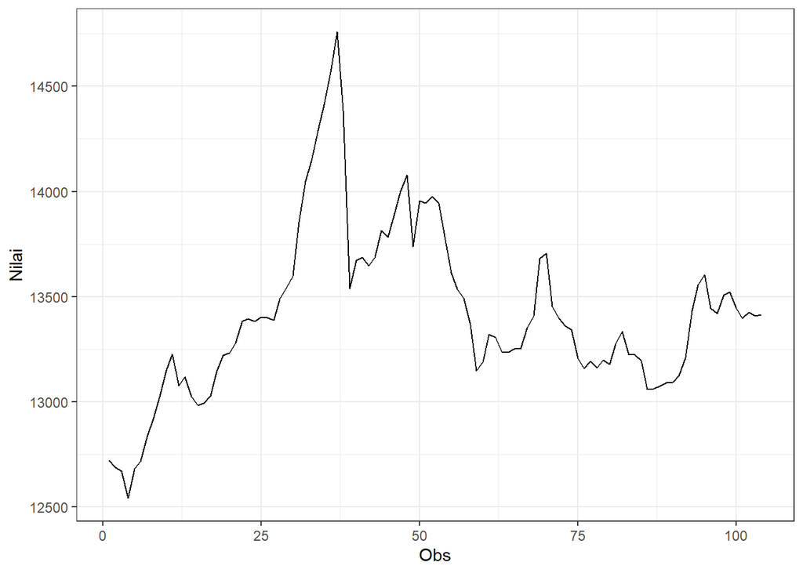

```r
df_ts <- as_tsibble(df, index = `Minggu Ke-`)

library(ggplot2)

plot_df <- df_ts |>
  ggplot(aes(x = `Minggu Ke-`, y = `Kurs Jual Rataan`)) +
  geom_line() +
  theme_bw() +
  xlab("Obs") +
  ylab("Nilai")

plot_df
```

```r
mean(df$`Kurs Jual Rataan`)
```

```
## [1] 13415.54
```

Berdasarkan plot, data tidak terlihat stasioner dalam rataan karena terdapat tren naik pada data.

### Plot Density

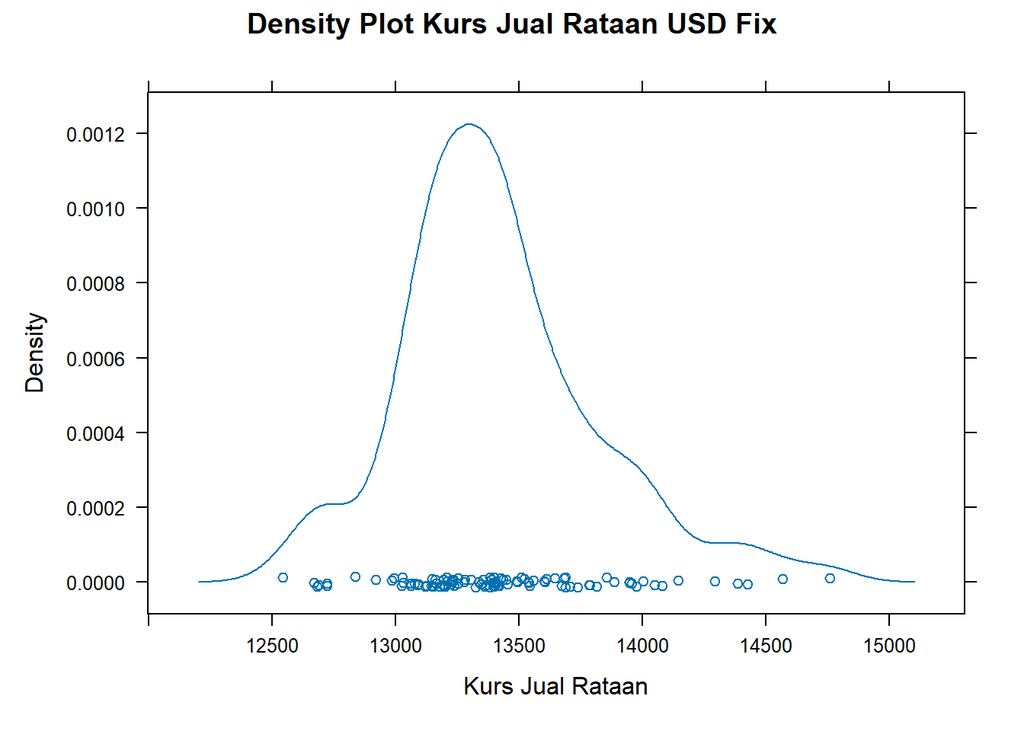

```r
lattice::densityplot(as.vector(df_ts$`Kurs Jual Rataan`),
                     main = "Density Plot Kurs Jual Rataan USD Fix",
                     xlab = "Kurs Jual Rataan")
```

Berdasarkan plot density, data tidak terlihat stasioner dalam varian karena bentuk kurva tidak menyerupai kurva normal.

### Plot ACF

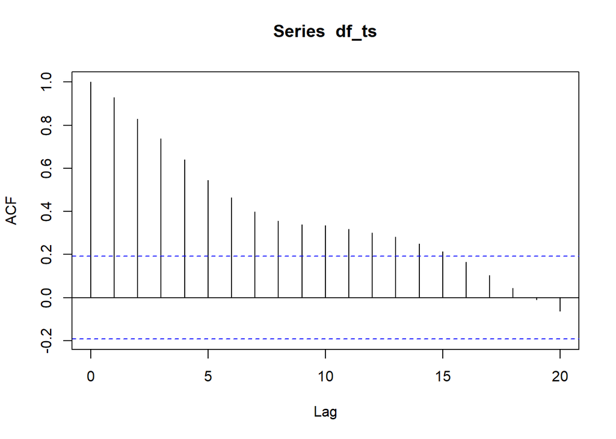

```r
acf(df_ts)
```

### Uji ADF

```r
tseries::adf.test(df_ts$`Kurs Jual Rataan`, k = 0)
```

```
##
##  Augmented Dickey-Fuller Test
##
## data:  df_ts$`Kurs Jual Rataan`
## Dickey-Fuller = -2.0913, Lag order = 0, p-value = 0.5388
## alternative hypothesis: stationary
```

$H_0$ : Data tidak stasioner dalam rataan

$H_1$ : Data stasioner dalam rataan

Berdasarkan uji ADF tersebut, didapat *p-value* sebesar 0.53 yang lebih besar dari taraf nyata 5% sehingga gagal tolak $H_0$ dan menandakan bahwa data tidak stasioner dalam rataan. Hal ini sesuai dengan hasil eksplorasi menggunakan plot time series dan plot ACF.

### Plot Box-Cox

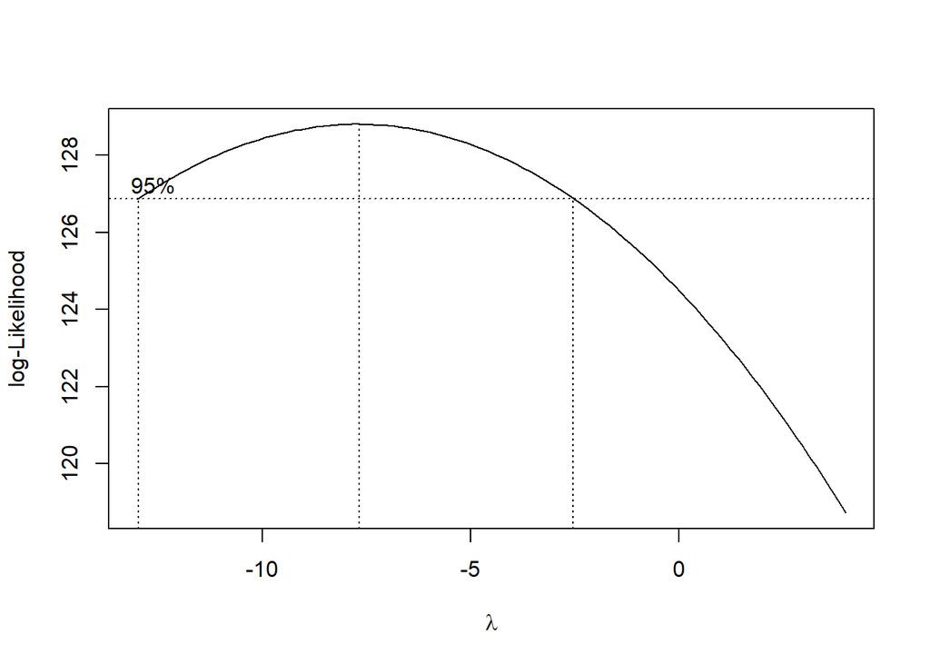

```r
index <- seq(1:104)
bc = boxcox(df_ts$`Kurs Jual Rataan`~index, lambda = seq(-13,4,by=1))
```

```r
#Nilai Rounded Lambda
lambda <- bc$x[which.max(bc$y)]
lambda
```

```
## [1] -7.676768
```

```r
#SK
bc$x[bc$y > max(bc$y) - 1/2 * qchisq(.95,1)]
```

```
##  [1] -12.828283 -12.656566 -12.484848 -12.313131 -12.141414 -11.969697
##  [7] -11.797980 -11.626263 -11.454545 -11.282828 -11.111111 -10.939394
## [13] -10.767677 -10.595960 -10.424242 -10.252525 -10.080808  -9.909091
## [19]  -9.737374  -9.565657  -9.393939  -9.222222  -9.050505  -8.878788
## [25]  -8.707071  -8.535354  -8.363636  -8.191919  -8.020202  -7.848485
## [31]  -7.676768  -7.505051  -7.333333  -7.161616  -6.989899  -6.818182
## [37]  -6.646465  -6.474747  -6.303030  -6.131313  -5.959596  -5.787879
## [43]  -5.616162  -5.444444  -5.272727  -5.101010  -4.929293  -4.757576
## [49]  -4.585859  -4.414141  -4.242424  -4.070707  -3.898990  -3.727273
## [55]  -3.555556  -3.383838  -3.212121  -3.040404  -2.868687  -2.696970
```

Plot box-cox menandakan nilai 1 tidak termasuk pada range rounded value optimum sehingga data tidak stasioner dalam ragam

## Partisi Data (80:20)

### Train Data

```r
train_size = floor(0.8 * length(df_ts$`Kurs Jual Rataan`))
train_data = df_ts$`Kurs Jual Rataan`[1:train_size]
print(train_data)
```

```
##  [1] 12723.0 12688.6 12670.6 12542.8 12681.6 12721.0 12837.2 12919.4 13025.4
## [10] 13151.2 13227.6 13076.6 13120.4 13026.8 12984.8 12994.6 13029.4 13143.6
## [19] 13221.8 13232.6 13280.2 13383.0 13395.2 13382.6 13403.0 13400.0 13388.8
## [28] 13491.6 13543.0 13599.8 13853.6 14049.8 14145.2 14291.2 14424.6 14567.2
## [37] 14758.2 14385.4 13540.6 13672.6 13688.0 13645.8 13686.0 13815.4 13783.0
## [46] 13885.6 14001.0 14079.2 13738.2 13956.0 13945.6 13976.0 13945.6 13785.4
## [55] 13611.6 13535.6 13490.8 13365.6 13148.0 13191.6 13322.0 13305.6 13235.2
## [64] 13236.6 13252.8 13253.0 13352.8 13407.4 13682.4 13707.4 13454.2 13396.4
## [73] 13359.6 13344.8 13206.2 13159.8 13193.8 13161.4 13198.6 13179.0 13276.2
## [82] 13335.4 13224.8
```

```r
mean(train_data)
```

```
## [1] 13439.69
```

```r
var(train_data)
```

```
## [1] 196028.7
```

#### Plot Time Series

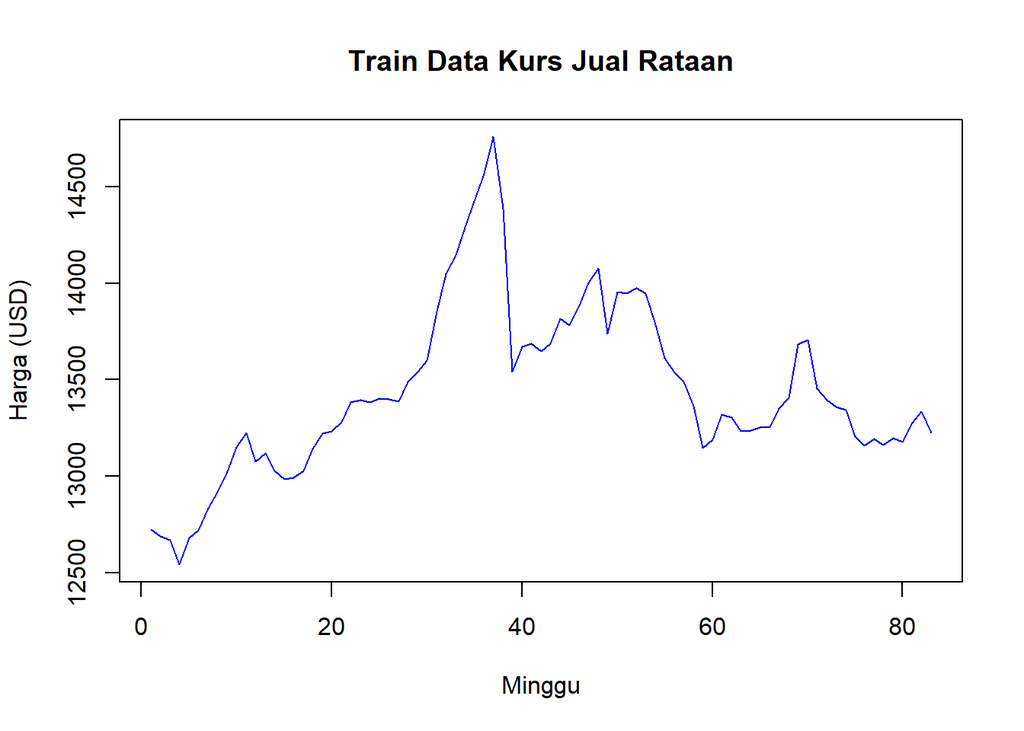

```r
plot.ts(train_data, main = "Train Data Kurs Jual Rataan", ylab = "Harga (USD)", xlab = "Minggu", col = "blue")
```

Berdasarkan plot, data train tidak terlihat stasioner dalam rataan karena terdapat tren naik pada data.

#### Plot ACF

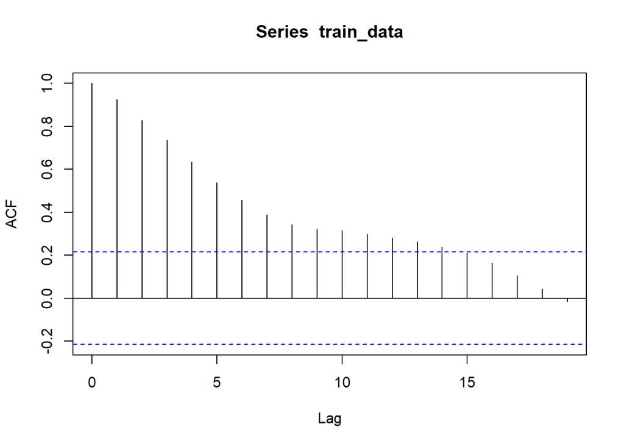

```r
acf(train_data)
```

Berdasarkan plot ACF, data train tidak terlihat stasioner dalam rataan karena terdapat nilai ACF yang melewati batas signifikan.

#### Uji ADF

```r
adf.test(train_data)
```

```
##
##  Augmented Dickey-Fuller Test
##
## data:  train_data
## Dickey-Fuller = -2.1517, Lag order = 4, p-value = 0.5136
## alternative hypothesis: stationary
```

$H_0$ : Data tidak stasioner dalam rataan

$H_1$ : Data stasioner dalam rataan

Berdasarkan uji ADF tersebut, didapat semua *p-value* lebih besar dari taraf nyata 5% sehingga gagal tolak $H_0$ dan menandakan bahwa data train tidak stasioner dalam rataan. Hal ini sesuai dengan hasil eksplorasi menggunakan plot time series dan plot ACF.

#### Plot Box-Cox

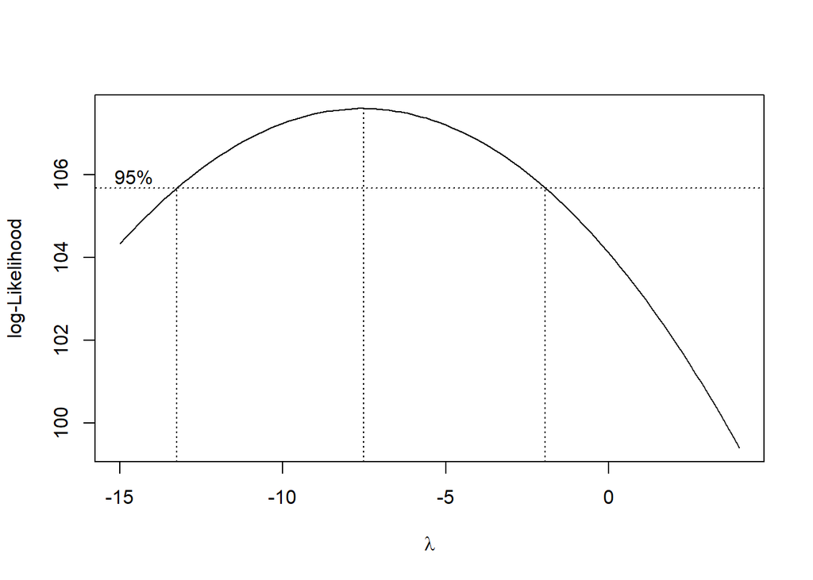

```r
idx = seq(1:length(train_data))
bx = boxcox(train_data~idx, lambda = seq(-15,4,by=1))
```

```r
#Nilai Rounded Lambda
lambda = bx$x[which.max(bx$y)]
lambda
```

```
## [1] -7.515152
```

```r
#SK
bx$x[bx$y > max(bx$y) - 1/2 * qchisq(.95,1)]
```

```
##  [1] -13.080808 -12.888889 -12.696970 -12.505051 -12.313131 -12.121212
##  [7] -11.929293 -11.737374 -11.545455 -11.353535 -11.161616 -10.969697
## [13] -10.777778 -10.585859 -10.393939 -10.202020 -10.010101  -9.818182
## [19]  -9.626263  -9.434343  -9.242424  -9.050505  -8.858586  -8.666667
## [25]  -8.474747  -8.282828  -8.090909  -7.898990  -7.707071  -7.515152
## [31]  -7.323232  -7.131313  -6.939394  -6.747475  -6.555556  -6.363636
## [37]  -6.171717  -5.979798  -5.787879  -5.595960  -5.404040  -5.212121
## [43]  -5.020202  -4.828283  -4.636364  -4.444444  -4.252525  -4.060606
## [49]  -3.868687  -3.676768  -3.484848  -3.292929  -3.101010  -2.909091
## [55]  -2.717172  -2.525253  -2.333333  -2.141414
```

Plot box-cox menandakan nilai 1 tidak termasuk pada range rounded value optimum sehingga data train tidak stasioner dalam ragam

### Test Data

```r
test_data = df_ts$`Kurs Jual Rataan`[(train_size + 1):length(df_ts$`Kurs Jual Rataan`)]
print(test_data)
```

```
##  [1] 13223.6 13195.6 13060.8 13062.4 13076.8 13089.8 13093.2 13124.8 13210.4
## [10] 13434.2 13556.4 13604.8 13446.8 13420.4 13508.4 13522.4 13447.0 13398.4
## [19] 13424.6 13407.4 13414.2
```

```r
mean(test_data)
```

```
## [1] 13320.11
```

```r
var(test_data)
```

```
## [1] 33719.38
```

#### Plot Time Series

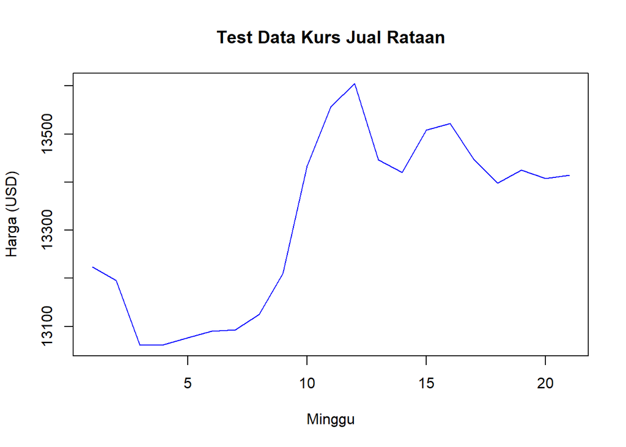

```r
plot.ts(test_data, main = "Test Data Kurs Jual Rataan", ylab = "Harga (USD)", xlab = "Minggu", col = "blue")
```

Berdasarkan plot, data test tidak terlihat stasioner dalam rataan karena terdapat tren naik pada data.

#### Plot ACF

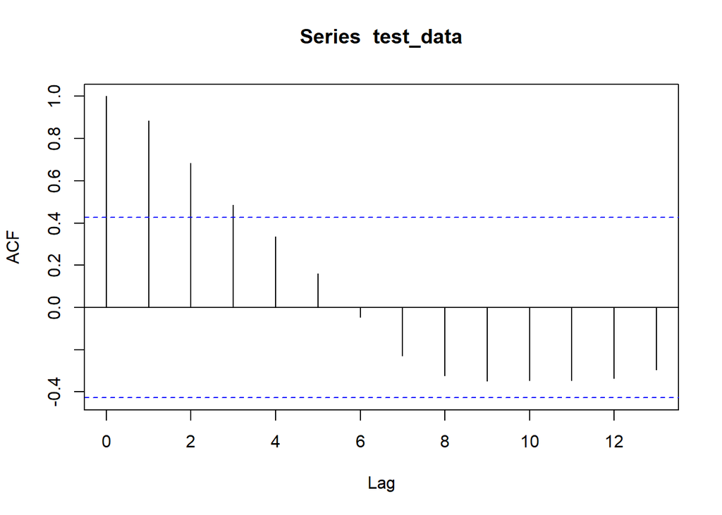

```r
acf(test_data)
```

Berdasarkan plot ACF, data test tidak terlihat stasioner dalam rataan karena menunjukkan pola tails off dan tidak langsung cut off.

#### Uji ADF

```r
adf.test(test_data)
```

```
##
##  Augmented Dickey-Fuller Test
##
## data:  test_data
## Dickey-Fuller = -1.3192, Lag order = 2, p-value = 0.8317
## alternative hypothesis: stationary
```

$H_0$ : Data tidak stasioner dalam rataan

$H_1$ : Data stasioner dalam rataan

Berdasarkan uji ADF tersebut, didapat semua *p-value* lebih besar dari taraf nyata 5% sehingga gagal tolak $H_0$ dan menandakan bahwa data test tidak stasioner dalam rataan. Hal ini sesuai dengan hasil eksplorasi menggunakan plot time series dan plot ACF.

#### Plot Box-Cox

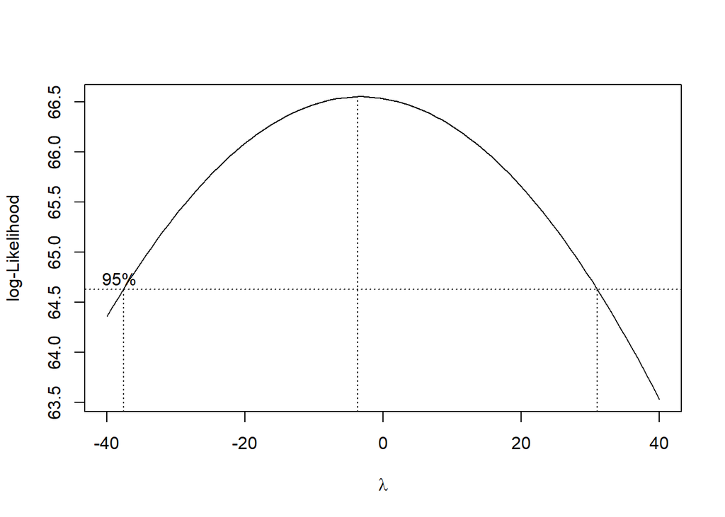

```r
idy = seq((train_size + 1):length(df_ts$`Kurs Jual Rataan`))
by = boxcox(test_data~idy, lambda = seq(-40,40,by=1))
```

```r
#Nilai Rounded Lambda
lambda = by$x[which.max(by$y)]
lambda
```

```
## [1] -3.636364
```

```r
#SK
by$x[by$y > max(by$y) - 1/2 * qchisq(.95,1)]
```

```
##  [1] -37.5757576 -36.7676768 -35.9595960 -35.1515152 -34.3434343 -33.5353535
##  [7] -32.7272727 -31.9191919 -31.1111111 -30.3030303 -29.4949495 -28.6868687
## [13] -27.8787879 -27.0707071 -26.2626263 -25.4545455 -24.6464646 -23.8383838
## [19] -23.0303030 -22.2222222 -21.4141414 -20.6060606 -19.7979798 -18.9898990
## [25] -18.1818182 -17.3737374 -16.5656566 -15.7575758 -14.9494949 -14.1414141
## [31] -13.3333333 -12.5252525 -11.7171717 -10.9090909 -10.1010101  -9.2929293
## [37]  -8.4848485  -7.6767677  -6.8686869  -6.0606061  -5.2525253  -4.4444444
## [43]  -3.6363636  -2.8282828  -2.0202020  -1.2121212  -0.4040404   0.4040404
## [49]   1.2121212   2.0202020   2.8282828   3.6363636   4.4444444   5.2525253
## [55]   6.0606061   6.8686869   7.6767677   8.4848485   9.2929293  10.1010101
## [61]  10.9090909  11.7171717  12.5252525  13.3333333  14.1414141  14.9494949
## [67]  15.7575758  16.5656566  17.3737374  18.1818182  18.9898990  19.7979798
## [73]  20.6060606  21.4141414  22.2222222  23.0303030  23.8383838  24.6464646
## [79]  25.4545455  26.2626263  27.0707071  27.8787879  28.6868687  29.4949495
## [85]  30.3030303
```

Plot box-cox menandakan nilai 1 termasuk pada range rounded value optimum sehingga data test stasioner dalam ragam

## Penanganan

### Transformasi data

#### Transformasi log (λ = 0) karena lambda optimum terlalu besar nilainya (λ =-7.68)

```r
library(forecast)
```

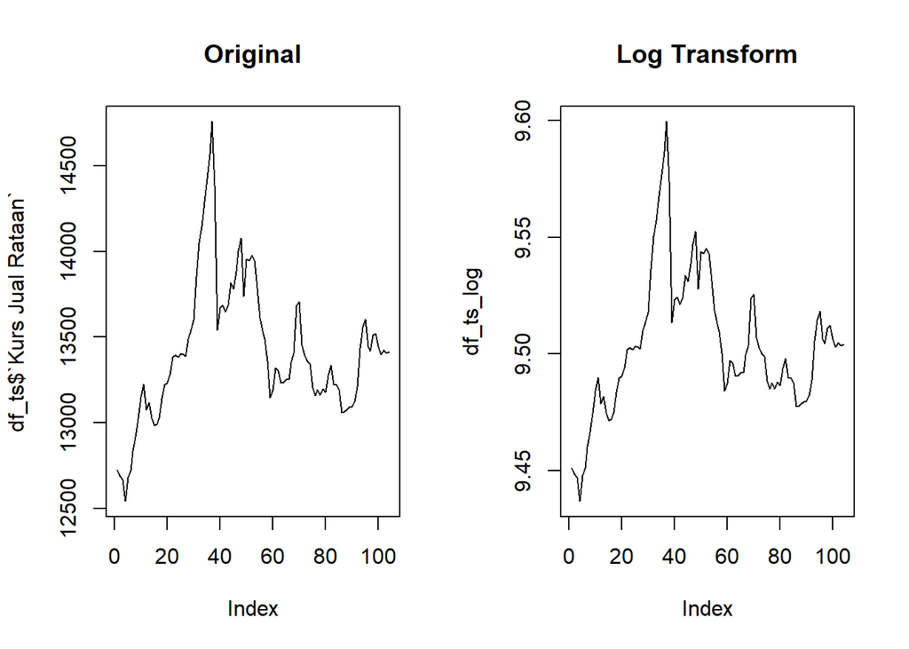

```r
df_ts_log <- log(df_ts$`Kurs Jual Rataan`)

par(mfrow=c(1,2))
plot(df_ts$`Kurs Jual Rataan`, main="Original", type="l")
plot(df_ts_log, main="Log Transform", type="l")
```

karena nilai lambda optimum terlalu besar, menyebabkan hasil transformasi menjadi tidak wajar. Oleh karena itu, digunakan lambda = 0 (log transform) untuk mentransformasi data. Hasil transformasi secara visual membuat data sedikit lebih stasioner dalam ragam

#### Plot Box-Cox Setelah Transformasi

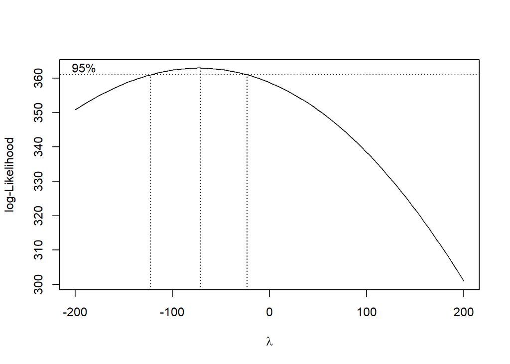

```r
b = boxcox(df_ts_log~index, lambda = seq(-200,200,by=20))
```

Plot box-cox menandakan nilai 1 tidak termasuk pada range rounded value optimum sehingga data log transform tidak stasioner dalam ragam. Ketidakstasioneran dalam ragam tidak dapat diatasi.

### Diferensiasi

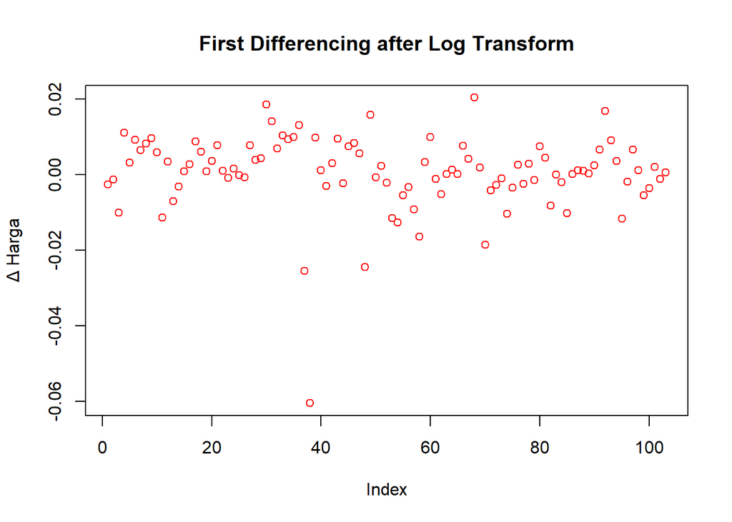

```r
df_ts_diff1 = diff(df_ts_log, differences = 1)

plot(df_ts_diff1, main = "First Differencing after Log Transform",
     ylab = "Δ Harga", col = "red")
```

#### Plot ACF Setelah Diferensiasi

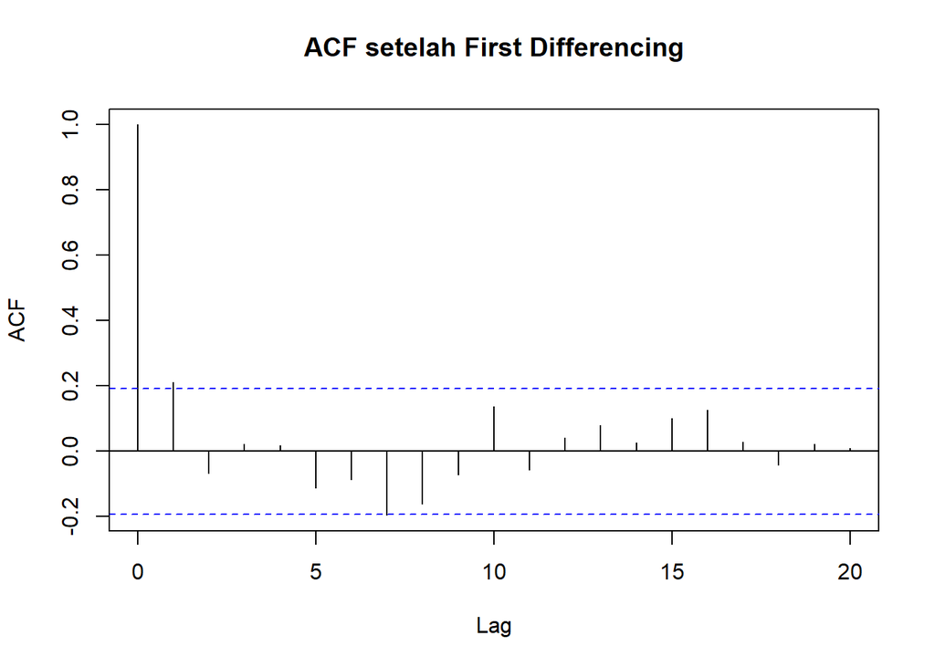

```r
acf(df_ts_diff1, main = "ACF setelah First Differencing")
```

Berdasarkan plot ACF, data terlihat stasioner dalam rataan karena langsung cut off.

#### Uji ADF Setelah Diferensiasi

```r
adf.test(df_ts_diff1)
```

```
##
##  Augmented Dickey-Fuller Test
##
## data:  df_ts_diff1
## Dickey-Fuller = -4.7488, Lag order = 4, p-value = 0.01
## alternative hypothesis: stationary
```

$H_0$ : Data tidak stasioner dalam rataan

$H_1$ : Data stasioner dalam rataan

Berdasarkan uji ADF tersebut, didapat *p-value* = 0.01 sehingga lebih kecil dari taraf nyata 5% sehingga tolak $H_0$ dan menandakan bahwa data setelah differencing stasioner dalam rataan. Hal ini sesuai dengan hasil eksplorasi menggunakan plot ACF.